# Capstone Project – The Battle of Neighborhoods | Finding a Better Place in Scarborough, Toronto

Thanks to all data sources.

**Author**: Peter Haro  
**Date**: August 2025  
**Description**:  
This project analyzes neighborhoods in Scarborough, Toronto using location data and clustering techniques.  
The goal is to help people find better places to live based on geographical and service-based data.

This notebook includes web scraping, data cleaning, and mapping using `folium` and clustering using `k-means`. Thanks to all data sources.

## 🔗 Contact

For any questions or collaborations, contact **Peter Haro** via [LinkedIn](https://www.linkedin.com/in/peter-haro-23a627230/) or Email or Company **More**: Software 7 AI Engineer @ HaroNext Innovations **Reach** https://haronext.com

### 1. Installing and Importing Python Libraries and Dependencies

[output not shown]

Importing Libraries

```
All Required Libraries Imported!
```

### 2. Data Extraction and Cleaning

Using BeautifulSoup Scraping List of Postal Codes of Given Wikipedia Page. Link: https://en.wikipedia.org/wiki/List_of_postal_codes_of_Canada:_M

Converting content of PostalCode HTML table as dataframe

|  | Postalcode | Borough | Neighborhood |
| --- | --- | --- | --- |
| 0 | M1B | Scarborough | Rouge, Malvern |
| 1 | M1C | Scarborough | Highland Creek, Rouge Hill, Port Union |
| 2 | M1E | Scarborough | Guildwood, Morningside, West Hill |
| 3 | M1G | Scarborough | Woburn |
| 4 | M1H | Scarborough | Cedarbrae |

|  | Postalcode | Borough | Neighborhood |
| --- | --- | --- | --- |
| count | 103 | 103 | 103 |
| unique | 103 | 11 | 103 |
| top | M2M | North York | York Mills West |
| freq | 1 | 24 | 1 |

|  | Postalcode | Borough | Neighborhood |
| --- | --- | --- | --- |
| 0 | M1B | Scarborough | Rouge, Malvern |
| 1 | M1C | Scarborough | Highland Creek, Rouge Hill, Port Union |
| 2 | M1E | Scarborough | Guildwood, Morningside, West Hill |
| 3 | M1G | Scarborough | Woburn |
| 4 | M1H | Scarborough | Cedarbrae |

|  | Postalcode | Borough | Neighborhood |
| --- | --- | --- | --- |
| count | 103 | 103 | 103 |
| unique | 103 | 11 | 103 |
| top | M2M | North York | York Mills West |
| freq | 1 | 24 | 1 |

```
(103, 3)
```

|  | Postalcode | Borough | Neighborhood |
| --- | --- | --- | --- |
| 0 | M1B | Scarborough | Rouge, Malvern |
| 1 | M1C | Scarborough | Highland Creek, Rouge Hill, Port Union |
| 2 | M1E | Scarborough | Guildwood, Morningside, West Hill |
| 3 | M1G | Scarborough | Woburn |
| 4 | M1H | Scarborough | Cedarbrae |

```
[43.70949500000006, -79.36398897099997]
```

|  | Postalcode | Borough | Neighborhood | Latitude | Longitude |
| --- | --- | --- | --- | --- | --- |
| 57 | M5G | Downtown Toronto | Central Bay Street | 43.656091 | -79.38493 |

|  | Postalcode | Borough | Neighborhood | Latitude | Longitude |
| --- | --- | --- | --- | --- | --- |
| 0 | M1B | Scarborough | Rouge, Malvern | 43.811525 | -79.195517 |
| 1 | M1C | Scarborough | Highland Creek, Rouge Hill, Port Union | 43.785665 | -79.158725 |
| 2 | M1E | Scarborough | Guildwood, Morningside, West Hill | 43.765815 | -79.175193 |
| 3 | M1G | Scarborough | Woburn | 43.768369 | -79.217590 |
| 4 | M1H | Scarborough | Cedarbrae | 43.769688 | -79.239440 |
| 5 | M1J | Scarborough | Scarborough Village | 43.743125 | -79.231750 |
| 6 | M1K | Scarborough | East Birchmount Park, Ionview, Kennedy Park | 43.726276 | -79.263625 |
| 7 | M1L | Scarborough | Clairlea, Golden Mile, Oakridge | 43.713054 | -79.285055 |
| 8 | M1M | Scarborough | Cliffcrest, Cliffside, Scarborough Village West | 43.724235 | -79.227925 |
| 9 | M1N | Scarborough | Birch Cliff, Cliffside West | 43.696770 | -79.259967 |

[output not shown]

### 3. Map of Scarborough

[interactive chart not shown]

```
The Geograpical Co-ordinate of Neighborhood_1 are 43.773077, -79.257774.
```

```
Your credentails:
CLIENT_ID: DPBYY4JUY3DU20ALPSUV4ONY2K1GOJJKJ1NIHBB32XEMOVYY
CLIENT_SECRET: 1MV443TYEP4HUO0WDUW5NQ5W10L2Y4G05NWG11WIR3NUGC5B
```

```
Index(['reasons.count', 'reasons.items', 'referralId', 'venue.categories',
       'venue.events.count', 'venue.events.summary', 'venue.id',
       'venue.location.address', 'venue.location.cc', 'venue.location.city',
       'venue.location.country', 'venue.location.crossStreet',
       'venue.location.distance', 'venue.location.formattedAddress',
       'venue.location.labeledLatLngs', 'venue.location.lat',
       'venue.location.lng', 'venue.location.neighborhood',
       'venue.location.postalCode', 'venue.location.state', 'venue.name',
       'venue.photos.count', 'venue.photos.groups', 'venue.venuePage.id'],
      dtype='object')
```

### 4. Nearby Venues/Locations

|  | venue.name | venue.categories | venue.location.lat | venue.location.lng |
| --- | --- | --- | --- | --- |
| 0 | Disney Store | [{'id': '4bf58dd8d48988d1f3941735', 'name': 'T... | 43.775537 | -79.256833 |
| 1 | American Eagle Outfitters | [{'id': '4bf58dd8d48988d103951735', 'name': 'C... | 43.775908 | -79.258352 |
| 2 | SEPHORA | [{'id': '4bf58dd8d48988d10c951735', 'name': 'C... | 43.775017 | -79.258109 |
| 3 | Canyon Creek Chophouse | [{'id': '4bf58dd8d48988d1cc941735', 'name': 'S... | 43.776959 | -79.261694 |
| 4 | Coliseum Scarborough Cinemas | [{'id': '4bf58dd8d48988d17f941735', 'name': 'M... | 43.775995 | -79.255649 |

### 5. Categories of Nearby Venues/Locations

|  | name | categories | lat | lng |
| --- | --- | --- | --- | --- |
| 0 | Disney Store | Toy / Game Store | 43.775537 | -79.256833 |
| 1 | American Eagle Outfitters | Clothing Store | 43.775908 | -79.258352 |
| 2 | SEPHORA | Cosmetics Shop | 43.775017 | -79.258109 |
| 3 | Canyon Creek Chophouse | Steakhouse | 43.776959 | -79.261694 |
| 4 | Coliseum Scarborough Cinemas | Movie Theater | 43.775995 | -79.255649 |

```
Clothing Store         8
Coffee Shop            5
Restaurant             3
Cosmetics Shop         3
Sporting Goods Shop    2
Pharmacy               2
Wings Joint            2
Tea Room               2
Sandwich Place         2
Electronics Store      1
Name: categories, dtype: int64
```

```
Rouge, Malvern
Highland Creek, Rouge Hill, Port Union
Guildwood, Morningside, West Hill
Woburn
Cedarbrae
Scarborough Village
East Birchmount Park, Ionview, Kennedy Park
Clairlea, Golden Mile, Oakridge
Cliffcrest, Cliffside, Scarborough Village West
Birch Cliff, Cliffside West
Dorset Park, Scarborough Town Centre, Wexford Heights
Maryvale, Wexford
Agincourt
Clarks Corners, Sullivan, Tam O'Shanter
Agincourt North, L'Amoreaux East, Milliken, Steeles East
L'Amoreaux West
Upper Rouge
Hillcrest Village
Fairview, Henry Farm, Oriole
Bayview Village
Silver Hills, York Mills
Newtonbrook, Willowdale
Willowdale South
York Mills West
Willowdale West
Parkwoods
Don Mills North
Flemingdon Park, Don Mills South
Bathurst Manor, Downsview North, Wilson Heights
Northwood Park, York University
CFB Toronto, Downsview East
Downsview West
Downsview Central
Downsview Northwest
Victoria Village
Woodbine Gardens, Parkview Hill
Woodbine Heights
The Beaches
Leaside
Thorncliffe Park
```

[output cut: 48 more lines]

```
Humber Bay Shores, Mimico South, New Toronto
Alderwood, Long Branch
The Kingsway, Montgomery Road, Old Mill North
Humber Bay, King's Mill Park, Kingsway Park South East, Mimico NE, Old Mill South, The Queensway East, Royal York South East, Sunnylea
Kingsway Park South West, Mimico NW, The Queensway West, Royal York South West, South of Bloor
Islington Avenue
Cloverdale, Islington, Martin Grove, Princess Gardens, West Deane Park
Bloordale Gardens, Eringate, Markland Wood, Old Burnhamthorpe
Humber Summit
Emery, Humberlea
Weston
Westmount
Kingsview Village, Martin Grove Gardens, Richview Gardens, St. Phillips
Albion Gardens, Beaumond Heights, Humbergate, Jamestown, Mount Olive, Silverstone, South Steeles, Thistletown
Northwest
```

```
There are 299 Uniques Categories.
```

| Neighborhood | Neighborhood Latitude | Neighborhood Longitude | Venue | Venue Latitude | Venue Longitude | Venue Category |
| --- | --- | --- | --- | --- | --- | --- |
| Adelaide, King, Richmond | 100 | 100 | 100 | 100 | 100 | 100 |
| Agincourt | 29 | 29 | 29 | 29 | 29 | 29 |
| Agincourt North, L'Amoreaux East, Milliken, Steeles East | 4 | 4 | 4 | 4 | 4 | 4 |
| Albion Gardens, Beaumond Heights, Humbergate, Jamestown, Mount Olive, Silverstone, South Steeles, Thistletown | 12 | 12 | 12 | 12 | 12 | 12 |
| Alderwood, Long Branch | 9 | 9 | 9 | 9 | 9 | 9 |

### One Hot Encoding of Features

|  | Zoo Exhibit | Accessories Store | Afghan Restaurant | African Restaurant | Airport | American Restaurant | Antique Shop | Arcade | Art Gallery | Art Museum | Arts & Crafts Store | Asian Restaurant | Athletics & Sports | Auto Dealership | BBQ Joint | Baby Store | Bagel Shop | Bakery | Bank | Bar | Baseball Field | Basketball Stadium | Beach | Beer Bar | Beer Store | Belgian Restaurant | Big Box Store | Bike Rental / Bike Share | Bike Shop | … |
| --- | --- | --- | --- | --- | --- | --- | --- | --- | --- | --- | --- | --- | --- | --- | --- | --- | --- | --- | --- | --- | --- | --- | --- | --- | --- | --- | --- | --- | --- | --- |
| 0 | 0 | 0 | 0 | 0 | 0 | 0 | 0 | 0 | 0 | 0 | 0 | 0 | 0 | 0 | 0 | 0 | 0 | 0 | 0 | 0 | 0 | 0 | 0 | 0 | 0 | 0 | 0 | 0 | 0 | … |
| 1 | 0 | 0 | 0 | 0 | 0 | 0 | 0 | 0 | 0 | 0 | 0 | 0 | 0 | 0 | 0 | 0 | 0 | 0 | 0 | 0 | 0 | 0 | 0 | 0 | 0 | 0 | 0 | 0 | 0 | … |
| 2 | 1 | 0 | 0 | 0 | 0 | 0 | 0 | 0 | 0 | 0 | 0 | 0 | 0 | 0 | 0 | 0 | 0 | 0 | 0 | 0 | 0 | 0 | 0 | 0 | 0 | 0 | 0 | 0 | 0 | … |
| 3 | 0 | 0 | 0 | 0 | 0 | 0 | 0 | 0 | 0 | 0 | 0 | 0 | 0 | 0 | 0 | 0 | 0 | 0 | 0 | 0 | 0 | 0 | 0 | 0 | 0 | 0 | 0 | 0 | 0 | … |
| 4 | 0 | 0 | 0 | 0 | 0 | 0 | 0 | 0 | 0 | 0 | 0 | 0 | 0 | 0 | 0 | 0 | 0 | 0 | 0 | 1 | 0 | 0 | 0 | 0 | 0 | 0 | 0 | 0 | 0 | … |

```
---- Adelaide, King, Richmond ----
          venue  freq
0   Coffee Shop  0.09
1          Café  0.07
2         Hotel  0.06
3  Burger Joint  0.03
4           Bar  0.03


---- Agincourt ----
                  venue  freq
0         Shopping Mall  0.07
1    Chinese Restaurant  0.07
2  Hong Kong Restaurant  0.03
3   Filipino Restaurant  0.03
4   Shanghai Restaurant  0.03


---- Agincourt North, L'Amoreaux East, Milliken, Steeles East ----
              venue  freq
0          Pharmacy  0.50
1    Sandwich Place  0.25
2  Sushi Restaurant  0.25
3       Zoo Exhibit  0.00
4     Movie Theater  0.00


---- Albion Gardens, Beaumond Heights, Humbergate, Jamestown, Mount Olive, Silverstone, South Steeles, Thistletown ----
                 venue  freq
0        Grocery Store  0.17
1       Hardware Store  0.08
2  Fried Chicken Joint  0.08
3       Sandwich Place  0.08
4       Discount Store  0.08


---- Alderwood, Long Branch ----
               venue  freq
0  Convenience Store  0.11
1        Coffee Shop  0.11
```

[output cut: 861 more lines]

```
            venue  freq
0        Bus Line  0.06
1     Pizza Place  0.06
2     Coffee Shop  0.06
3   Grocery Store  0.06
4  Sandwich Place  0.06


---- York Mills West ----
           venue  freq
0    Coffee Shop  0.16
1     Restaurant  0.12
2            Gym  0.12
3  Burrito Place  0.04
4           Bank  0.04
```

### Most Common venues near neighborhood

|  | Neighborhood | 1st Most Common Venue | 2nd Most Common Venue | 3rd Most Common Venue | 4th Most Common Venue | 5th Most Common Venue | 6th Most Common Venue | 7th Most Common Venue | 8th Most Common Venue | 9th Most Common Venue | 10th Most Common Venue |
| --- | --- | --- | --- | --- | --- | --- | --- | --- | --- | --- | --- |
| 0 | Adelaide, King, Richmond | Coffee Shop | Café | Hotel | Gastropub | Burger Joint | Asian Restaurant | Bar | Restaurant | American Restaurant | Steakhouse |
| 1 | Agincourt | Chinese Restaurant | Shopping Mall | Pizza Place | Supermarket | Sushi Restaurant | Breakfast Spot | Print Shop | Mediterranean Restaurant | Coffee Shop | Pool |
| 2 | Agincourt North, L'Amoreaux East, Milliken, St... | Pharmacy | Sandwich Place | Sushi Restaurant | Doner Restaurant | Donut Shop | Dumpling Restaurant | Eastern European Restaurant | Electronics Store | Elementary School | Ethiopian Restaurant |
| 3 | Albion Gardens, Beaumond Heights, Humbergate, ... | Grocery Store | Park | Sandwich Place | Discount Store | Japanese Restaurant | Fried Chicken Joint | Beer Store | Hardware Store | Pizza Place | Fast Food Restaurant |
| 4 | Alderwood, Long Branch | Convenience Store | Pub | Sandwich Place | Coffee Shop | Gas Station | Dance Studio | Gym | Pharmacy | Pizza Place | Falafel Restaurant |

### K-Means Clustering Approach

```
array([0, 0, 0, 0, 0, 0, 2, 0, 0, 2, 0, 0, 0, 0, 0, 0, 0, 0, 0, 0, 0, 0,
       0, 0, 0, 0, 0, 0, 0, 0, 0, 0, 0, 0, 2, 0, 0, 0, 0, 2, 0, 0, 0, 0,
       0, 0, 0, 0, 2, 0, 0, 0, 0, 0, 2, 0, 0, 0, 0, 0, 0, 0, 0, 0, 0, 0,
       0, 0, 2, 0, 0, 0, 0, 0, 2, 0, 2, 0, 0, 0, 0, 0, 1, 0, 0, 0, 0, 0,
       0, 0, 2, 0, 0, 0, 0, 0, 0, 0, 0, 0, 0, 0], dtype=int32)
```

|  | Postalcode | Borough | Neighborhood | Latitude | Longitude | Cluster Labels | 1st Most Common Venue | 2nd Most Common Venue | 3rd Most Common Venue | 4th Most Common Venue | 5th Most Common Venue | 6th Most Common Venue | 7th Most Common Venue | 8th Most Common Venue | 9th Most Common Venue | 10th Most Common Venue |
| --- | --- | --- | --- | --- | --- | --- | --- | --- | --- | --- | --- | --- | --- | --- | --- | --- |
| 0 | M1B | Scarborough | Rouge, Malvern | 43.811525 | -79.195517 | 0 | Zoo Exhibit | Financial or Legal Service | Fast Food Restaurant | Construction & Landscaping | Fish & Chips Shop | Filipino Restaurant | Field | Fish Market | Farmers Market | Doner Restaurant |
| 1 | M1C | Scarborough | Highland Creek, Rouge Hill, Port Union | 43.785665 | -79.158725 | 0 | Bar | Falafel Restaurant | Donut Shop | Dumpling Restaurant | Eastern European Restaurant | Electronics Store | Elementary School | Ethiopian Restaurant | Event Space | Yoga Studio |
| 2 | M1E | Scarborough | Guildwood, Morningside, West Hill | 43.765815 | -79.175193 | 2 | Park | Gym / Fitness Center | Pool | Fried Chicken Joint | Indian Restaurant | Athletics & Sports | Ethiopian Restaurant | Donut Shop | Dumpling Restaurant | Eastern European Restaurant |
| 3 | M1G | Scarborough | Woburn | 43.768369 | -79.217590 | 0 | Coffee Shop | Fast Food Restaurant | Business Service | Park | Yoga Studio | Dumpling Restaurant | Eastern European Restaurant | Electronics Store | Elementary School | Ethiopian Restaurant |
| 4 | M1H | Scarborough | Cedarbrae | 43.769688 | -79.239440 | 0 | Flower Shop | Athletics & Sports | Thai Restaurant | Bank | Bakery | Caribbean Restaurant | Hakka Restaurant | Indian Restaurant | Eastern European Restaurant | Electronics Store |

### Map of Clusters

```
['#8000ff', '#4856fb', '#10a2f0', '#2adddd', '#62fbc4', '#9cfba4', '#d4dd80', '#ffa256', '#ff562c', '#ff0000']
```

[interactive chart not shown]

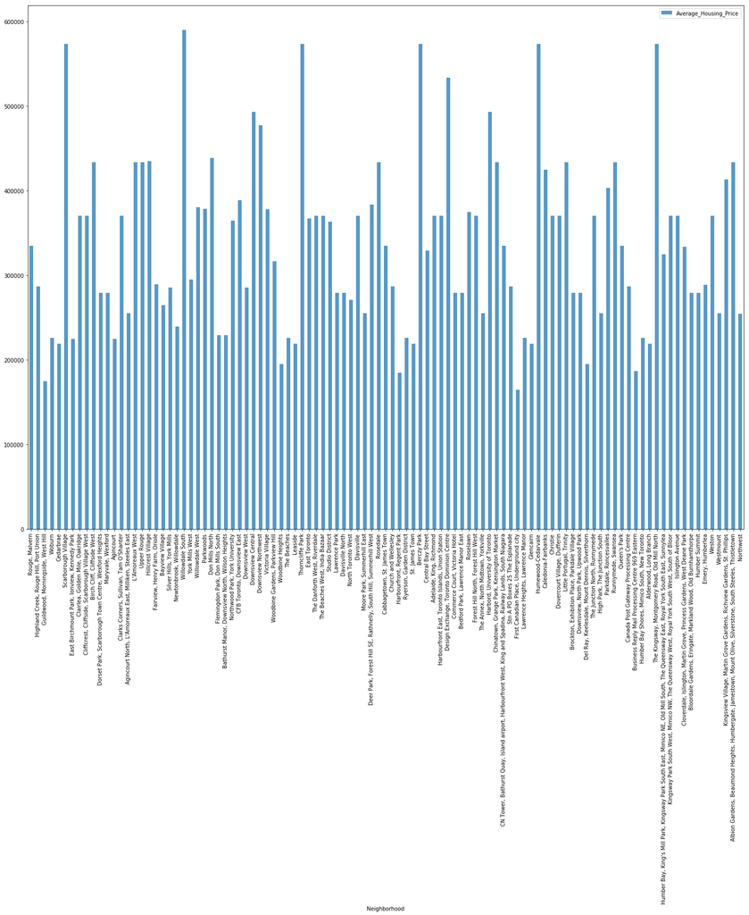

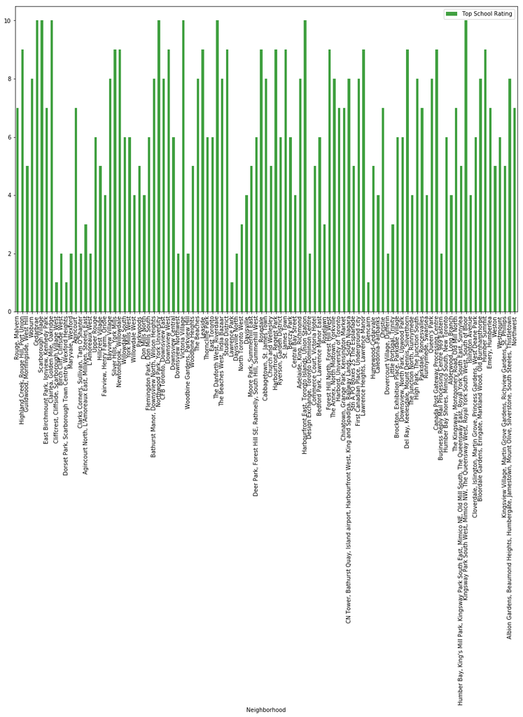